# 62地点分析报告

Kang

## 数据处理

原始数据为2018年间到达奄美群岛的所有手机用户每天的轨迹。原始数据为来自[Agoop公司的人口流动点数据](https://agoop.co.jp/service/dynamic-population-data/)，是每个用户在一天中不同时刻的位置信息。有些人轨迹比较多，有些人被收集到的轨迹比较少，所以需要对数据进行清理。数据清理过程主要包括如下步骤。

- 由于研究区域是奄美大岛和加计吕麻岛，因此首先将这两个岛屿范围之外的轨迹点去除。
- 从原始数据中去除轨迹点特别少的用户，因为如果轨迹点太少，我们无法分析其每天的移动轨迹。
- 由于主要活动时间段为上午4时到晚上10时，因此这些时间段之外的轨迹点也去除；对于每个用户，只保留每10分钟内最早的一个数据点，使每个用户的数据密度相对一致。

对于数据，需要注意的是，这里的”用户”是指一天内的一位独立用户，例如，有个人两天都待在奄美群岛上，则会被识别为两个用户号（在数据中被称为”daily ID”）。

## 数据描述

研究区域地图（包含62地点位置）、轨迹点分布状况等见附件图片。62个地点及其分组（北部组团、空港组团、城市组团、宇检村组团等）情况如下图。之后需要将加计吕麻岛南边岛两个小岛屿删除。

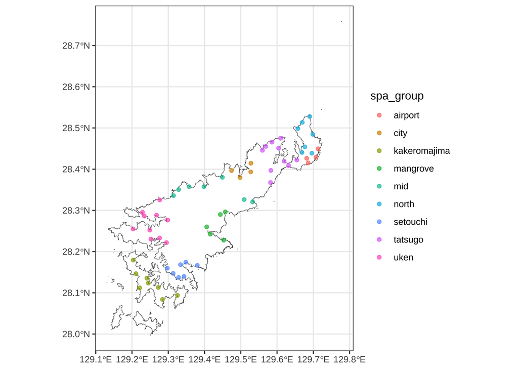

各个组团包含的节点数量如下。

```
##
##      airport         city kakeromajima     mangrove          mid        north
##            4            4            8            5            7            7
##     setouchi      tatsugo         uken
##            7           10           10
```

筛选后的Agoop数据的条数（轨迹点数量）和daily ID数如下。

```
## 原始数据条数： 2013895
##  原始数据中涉及的daily ID数： 43258
##  本地人和游客的轨迹点数量：
```

```
##
##   local tourist
## 1612810  401085
```

```
## 本地人和游客的daily ID数量：
```

```
##
##   local tourist
##   33497    9761
```

各季节各客源的daily ID数量如下。

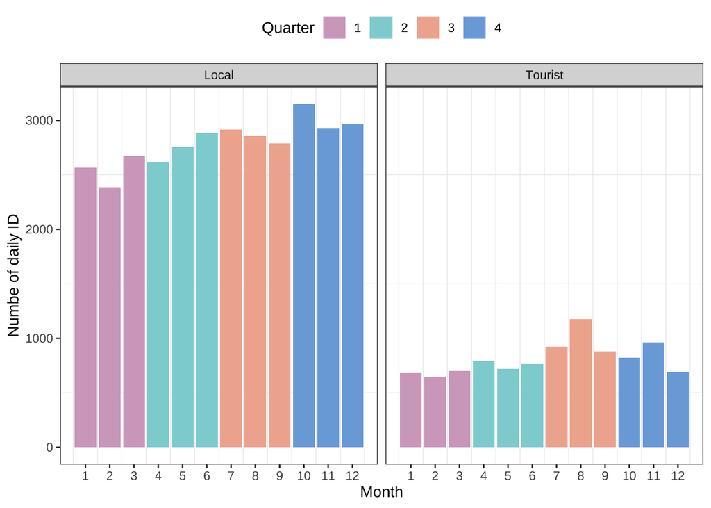

对应数据如下表。

| month | local | tourist |
| --- | --- | --- |
| 1 | 2564 | 683 |
| 2 | 2388 | 642 |
| 3 | 2672 | 701 |
| 4 | 2618 | 795 |
| 5 | 2755 | 720 |
| 6 | 2888 | 765 |
| 7 | 2915 | 926 |
| 8 | 2858 | 1175 |
| 9 | 2788 | 879 |
| 10 | 3153 | 824 |
| 11 | 2930 | 961 |
| 12 | 2968 | 690 |

## 地点网络指标

对于每个组团中的各个地点，不同客源、季度的中心度指标不同。可以用箱形图加统计对比，在此基础上用跳动点表示原始数据，点颜色表示季度。可见城市组团的节点各个网络指标都比较高。**问题：可以看出一些差异，如游客的空港-市中心差异比较小，且游客相对而言去市中心之外的其他地方更多，但是如何比较这种差异？统计分析？**

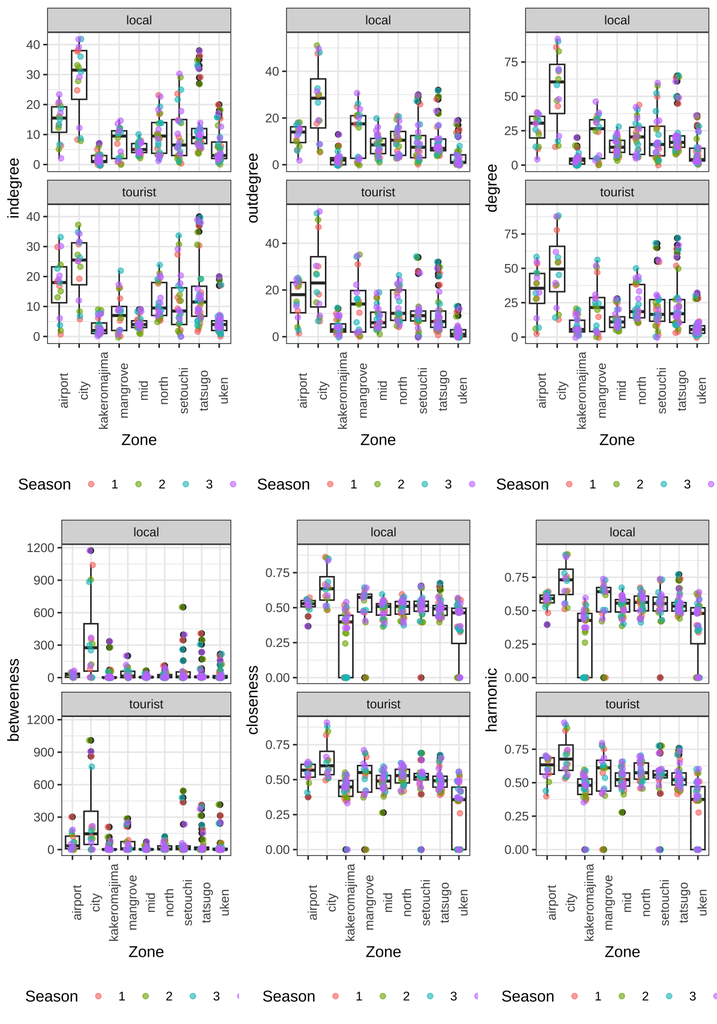

各组团各种指数的中位数如下。

[output not shown]

| vis_src | spa_group | indegree | outdegree | degree | closeness | harmonic | betweeness |
| --- | --- | --- | --- | --- | --- | --- | --- |
| local | airport | 15.5 | 14.0 | 30.5 | 0.5283485 | 0.5912130 | 29.8363755 |
| local | city | 31.5 | 28.5 | 60.5 | 0.6352585 | 0.7309575 | 276.2824745 |
| local | kakeromajima | 1.0 | 2.0 | 3.5 | 0.3979060 | 0.4274870 | 0.1666670 |
| local | mangrove | 9.5 | 17.5 | 26.5 | 0.5737065 | 0.6423450 | 14.6186190 |
| local | mid | 5.0 | 8.5 | 13.0 | 0.5088560 | 0.5564970 | 3.9927580 |
| local | north | 9.5 | 10.5 | 20.5 | 0.5091330 | 0.5625000 | 7.4298510 |
| local | setouchi | 6.5 | 7.5 | 15.0 | 0.5137610 | 0.5535715 | 7.0102205 |
| local | tatsugo | 9.0 | 7.0 | 16.5 | 0.4918010 | 0.5342505 | 6.2705005 |
| local | uken | 3.0 | 1.0 | 4.0 | 0.4633440 | 0.4798900 | 1.0915670 |
| tourist | airport | 18.0 | 18.0 | 35.5 | 0.5677275 | 0.6333100 | 34.7310915 |
| tourist | city | 25.5 | 23.0 | 49.5 | 0.5989080 | 0.6763890 | 145.9415990 |
| tourist | kakeromajima | 2.0 | 3.0 | 5.5 | 0.4473685 | 0.4802260 | 0.3785715 |
| tourist | mangrove | 7.0 | 14.0 | 21.5 | 0.5509260 | 0.6111110 | 7.2518900 |
| tourist | mid | 4.0 | 6.0 | 11.0 | 0.4897375 | 0.5225985 | 1.5503240 |
| tourist | north | 9.5 | 10.0 | 18.5 | 0.5288795 | 0.5742230 | 4.6797675 |
| tourist | setouchi | 8.5 | 9.0 | 16.5 | 0.5172410 | 0.5574390 | 9.1638450 |
| tourist | tatsugo | 11.5 | 6.5 | 17.0 | 0.4918030 | 0.5222220 | 5.7580115 |
| tourist | uken | 4.0 | 1.0 | 5.5 | 0.3571935 | 0.3750000 | 0.2527775 |

网络指标的空间分布如下（以indegree为例）。

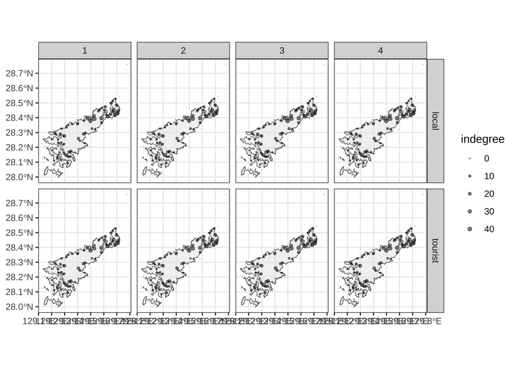

如果要比较不同客源的差异，可以用游客的指数数值除以本地人的数值。点比较大的是游客比较倾向于去的地方，比较小的是本地人比较倾向于去的地方。问题：需要找到一个更好的比较方法。

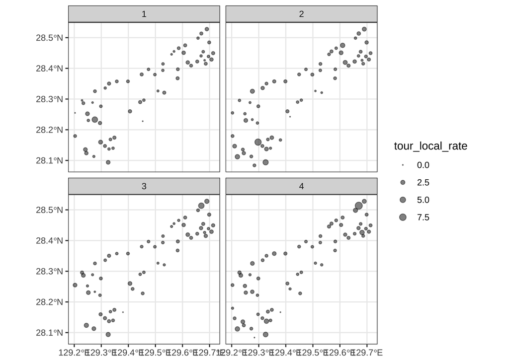

## 地点聚类

根据各地点的网络指标（目前选择了6个），可在各客源各季节下，对地点进行聚类分析。由于所有网络指标均为连续型变量，因此此处采用k-means聚类分析。和所有非监督聚类一样，在开始聚类之前，需要指定聚类后类别的数量。可以根据多种方法获得最佳聚类数量（此处略）。经分析，大部分客源-季节下，最佳聚类数量是3-4个，为了保持一致性，将所有客源-季节聚类分析中的聚类数量都定为3。以下是聚类结果：横纵轴表示降维后最主要的2个维度能够解释的原多维度空间的变异比例，越高越好；该二维图中通常越靠近的点越相近，相同颜色表示同一个聚类，其中红、绿、蓝分别代表1、2、3号聚类。

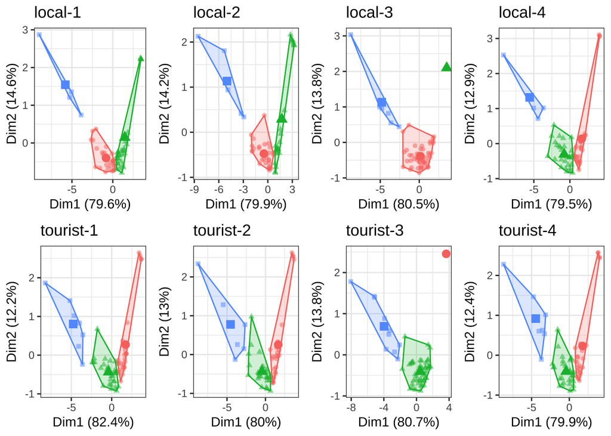

那么各个空间组团中的地点被分到那些聚类中呢？可以用桑基图表示。下图中各子图的排序和上图相同，即上面是local，下面是tourist。

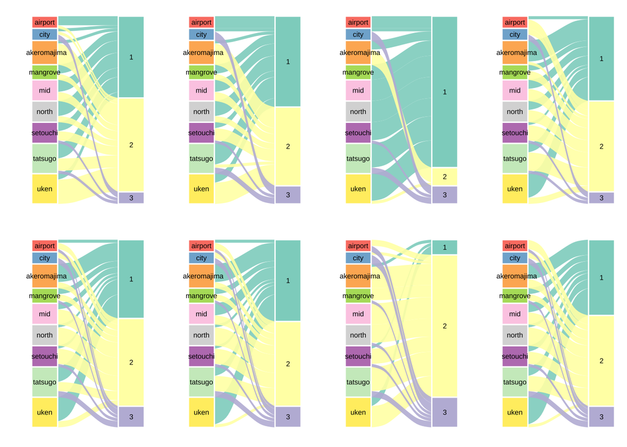

那么各种聚类有什么特征呢？要回到原始数据中，用雷达图表示。首先是local中1、2、4季度各聚类的雷达图（第3季度中缺失值太多，无法作图）。可以看出第1季度和第2季度比较相似：似乎第1号聚类比较均衡，第2号聚类则harmonic和closeness比较突出，第3号聚类数量太少难以判断。

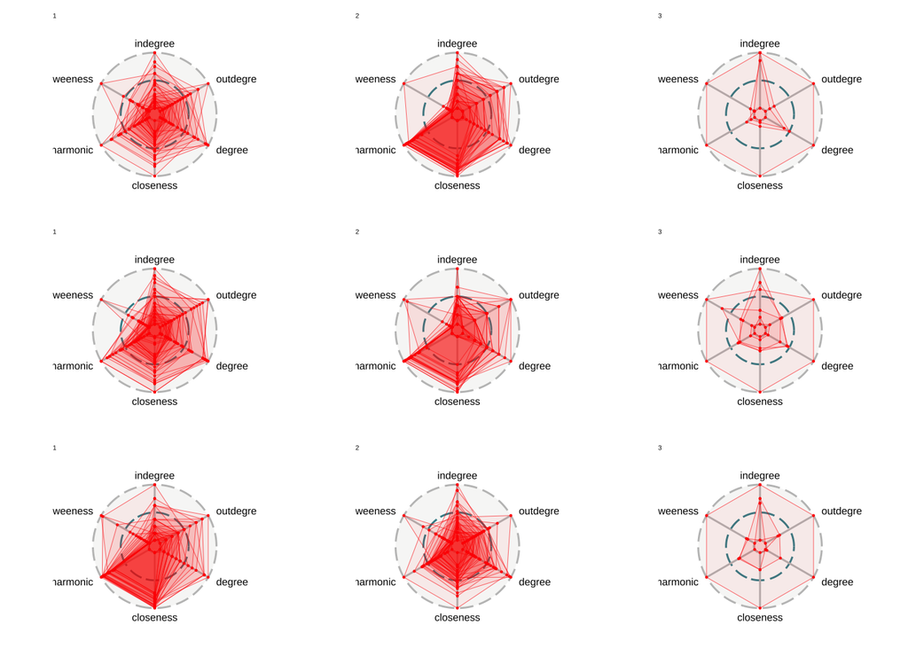

然后是tourist中1、2、4季度各聚类的的雷达图（类似地，刚好第3季度也是缺失值太多，无法作图；如果需要的话，或许可以通过一定技术手段解决）。

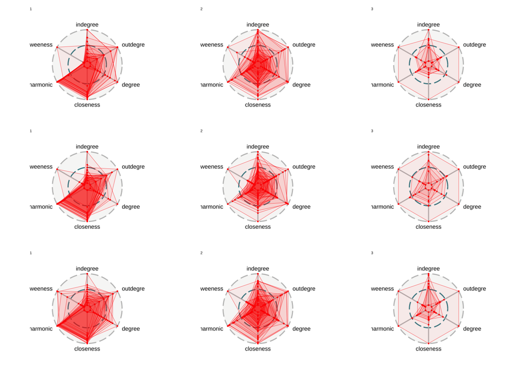

**问题：这个结果有什么涵义？和后面的结果是否要关联；如果要的话，如何关联？是否有必要分季节做？**

## 可达性指标

基于谢提供的不同POI可达性图层数据，计算POI可达性指标。对于每一类POI，对各个地点计算可达性指标如下：一个地点有步行和开车不同时间情况下的可达性图层，每个图层可计算一个该图层与地点多边形的重叠面积，那么，对于该地点该类POI的可达性指标为：各时间下可达性图层和该地点交叠面积的加权只和，此处权重为时间的倒数，也就是说，时间越短，权重越大，该可达性图层越重要。

$$0.4 \times \sum \text{WalkArea}_i \times walk\_w_i + 0.6 \times \sum
\text{DriveArea}_{i} \times drive\_w_i$$

## 连接供需

对各个节点的基础设施供需进行对比，以提供基础设施建设或服务投资的建议。主要思路是：以节点的网络指标表示需求，因为需求跟人类行为有关；对应的服务或基础设施POI可达性指标作为供给；对比节点的需求和供给，以标准化后的两者比率表示供给率。

各网络指标和服务之间进行匹配，匹配思路的例子如下：

- 对本地人：indegree高 - 作为目的地的吸引力强 - 对应本地服务，如市政中心；
- 对游客：indegree高 - 作为旅游目的地的吸引力强 - 对应应增加旅游基础设施如酒店、餐厅、景点；Betweenness高 - 从此处中转的人多 - 可作为交通枢纽；Closeness高 - 到其他点的”平均距离”小 - 可能是中心景点或具有中心景点潜力。

**目前的问题：对于每种需求，需要匹配一对网络指标和POI，这种匹配比较困难。**此前谢尝试进行了匹配，但是很多是多对一的匹配，这种匹配下，我们无法直接计算供需比——要一对一的匹配才能进行供需比。因此，我对这个多对一供需关系进行了修改，变成了一对一的关系。对于供需匹配，还需要进一步的讨论或者修改。当前的匹配如下：

- 对于本地人：市政-indegree，教育-indegree，公共娱乐-degree，健康-degree，零售-harmonic（问题：为何这么匹配？），住宿和食物-indegree。
- 对于旅客：住宿和食物-indgree，景点-indegree，公共娱乐- degree，交通-betweenness。

计算结果见附件表格，数据中各列对应数据为：

- vis_src：客源；season：季度id：地点编号； longitude和latitude：经纬度； indegree，outdegree，degree，closness_centrality，harmonicclosness_centrality，betweeness_centrality：中心度； ac，education等：POI可达性指数。
- local_ds_gov，local_ds_edu，local_ds_amen，tourist_ds_tour，tourist_ds_mobility - 对于不同客源的各类需求，例如local_ds_gov是对于本地人而言的市政服务需求（因此游客行中的数据不算数）。
- spa_group：空间组团。

我们可以逐一看看当前匹配并计算出来的几个供需结果。本地人各类供需匹配结果如下。

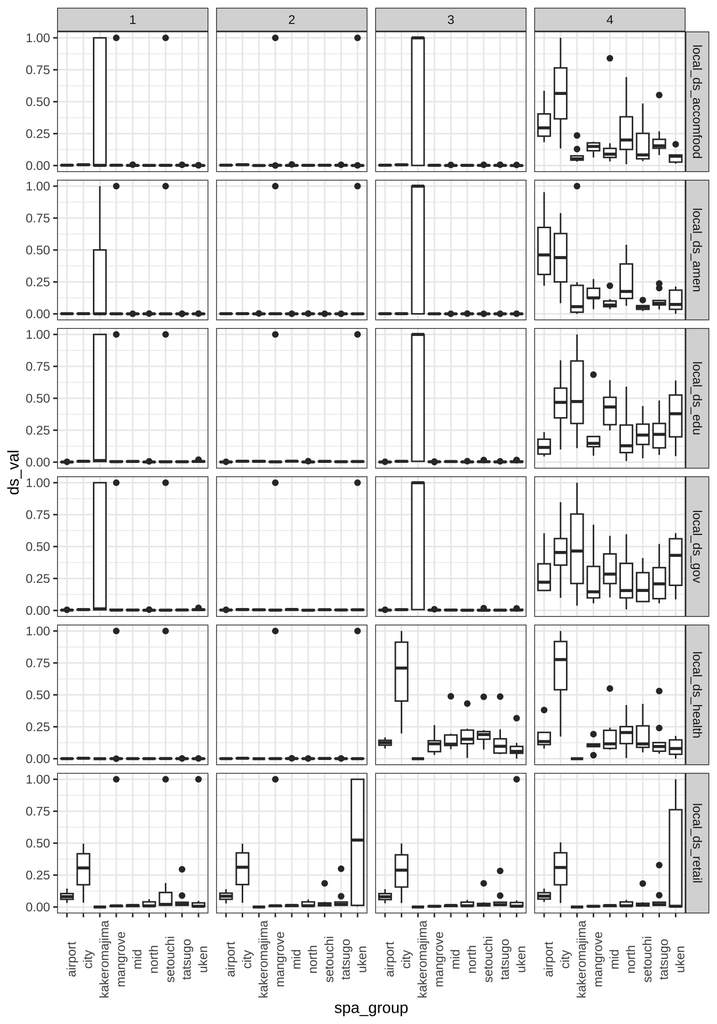

由于分布过于偏态，因此用对数尺度看看效果：

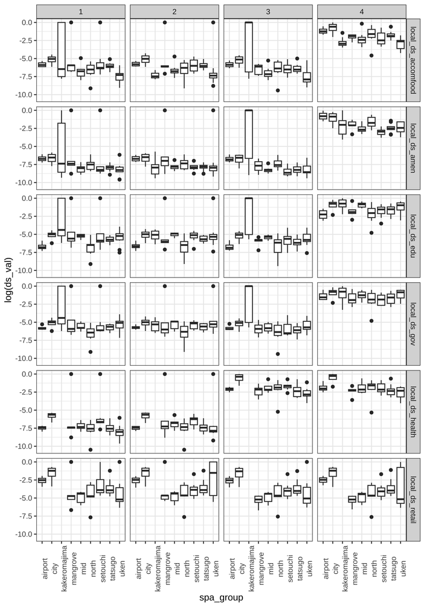

游客各项供需结果如下：

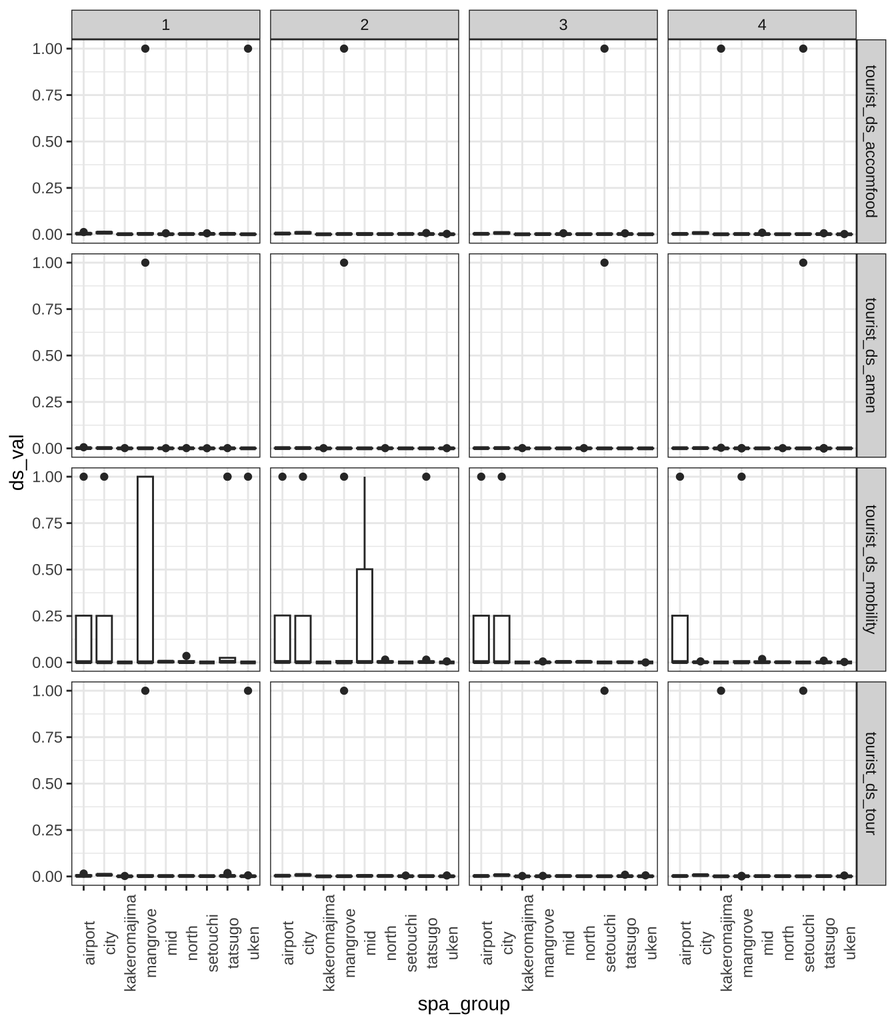

如果用对数尺度表现结果的话：

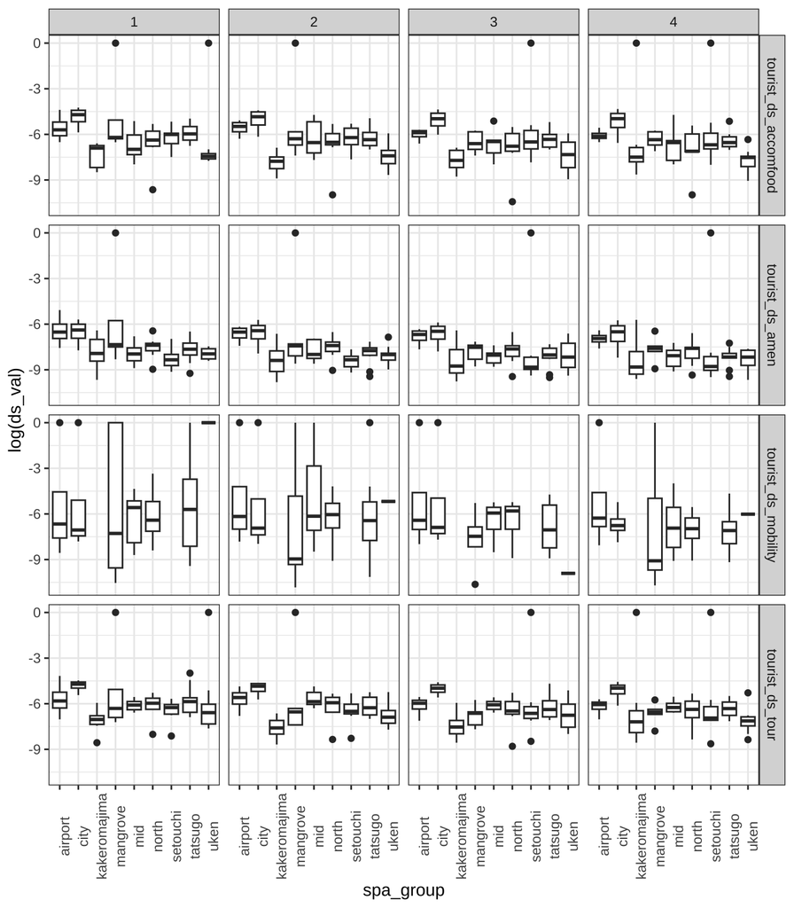